# Projeto Métodos de Aprendizagem Não supervisionados - PCA na base de dados com Imputação

# Tratamento dos dados

1. O PCA é mais eficaz quando as variáveis estão correlacionadas entre si.
2. Antes de aplicar o PCA, é importante verificar se as variáveis estão em escalas comparáveis. Variáveis em diferentes escalas podem ter diferentes variações e isso pode distorcer a análise do PCA.

## Selecionar Colunas

Devido ao elevado número de colunas, iremos primeiramente eliminar algumas colunas, a fim de facilitar o processo de aplicar o teste KMO, pois,torna-se computacionalmente intensiva

```r
colnames(IrlandaNoImput)
```

```
##  [1] "PV1SCIE"      "PV1READ"      "PV1MATH"      "SOCONPA"      "BODYIMA"
##  [6] "JOYREADP"     "PRESUPP"      "PASCHPOL"     "PQSCHOOL"     "EMOSUPP"
## [11] "CURSUPP"      "INFOJOB2"     "INFOJOB1"     "INFOCAR"      "ICTOUTSIDE"
## [16] "ICTCLASS"     "SOIAICT"      "AUTICT"       "COMPICT"      "INTICT"
## [21] "USESCH"       "HOMESCH"      "ENTUSE"       "BEINGBULLIED" "BELONG"
## [26] "MASTGOAL"     "RESILIENCE"   "SWBP"         "EUDMO"        "GFOFAIL"
## [31] "WORKMAST"     "COMPETE"      "ATTLNACT"     "PERCOMP"      "PISADIFF"
## [36] "SCREADDIFF"   "SCREADCOMP"   "JOYREAD"      "TEACHINT"     "ADAPTIVITY"
## [41] "STIMREAD"     "EMOSUPS"      "PERFEED"      "DIRINS"       "TEACHSUP"
## [46] "DISCLIMA"     "ICTRES"       "WEALTH"       "HEDRES"       "CULTPOSS"
## [51] "HOMEPOS"      "ICTSCH"       "ICTHOME"      "ESCS"         "CHANGE"
## [56] "SCCHANGE"     "SMINS"        "LMINS"        "MMINS"        "GRADE"
## [61] "ST061Q01NA"   "ST060Q01NA"   "ST059Q03TA"   "ST059Q02TA"   "ST059Q01TA"
## [66] "ST016Q01NA"   "IMMIG"        "HISEI"        "BFMJ2"        "BMMJ1"
## [71] "HISCED"       "FISCED"       "MISCED"       "ISCEDL"       "ST001D01T"
## [76] "REPEAT"
```

```r
# A variável GRADE faz com que o teste KMO dê erro (não se sabe)
# Aqui serão apagadas todas as variáveis que, ou podem ser substituidas, ou não tem valor nenhum

Apagar <- c("GRADE", "JOYREADP", "PRESUPP", "PQSCHOOL", "EMOSUPP", "CURSUPP", "INFOJOB2", "ICTOUTSIDE", "ICTCLASS", "INTICT", "ENTUSE", "ATTLNACT", "DISCLIMA", "ICTSCH", "ICTSCH", "REPEAT", "IMMIG", "FISCED", "MISCED", "PASCHPOL", "COMPETE", "SMINS", "ST061Q01NA", "ST060Q01NA", "ST059Q03TA", "PERCOMP", "CHANGE", "SCCHANGE", "BFMJ2", "BMMJ1")

IrlandaNoImput <- IrlandaNoImput[, -which(names(IrlandaNoImput) %in% Apagar)]
```

## Correlações das colunas

```r
CorrIrlandaNoImput <- cor(IrlandaNoImput)
```

## KMO measure

```r
kmo_result <- KMO(IrlandaNoImput)
kmo_result
```

```
## Kaiser-Meyer-Olkin factor adequacy
## Call: KMO(r = IrlandaNoImput)
## Overall MSA =  0.68
## MSA for each item =
##      PV1SCIE      PV1READ      PV1MATH      SOCONPA      BODYIMA     INFOJOB1
##         0.85         0.83         0.84         0.82         0.85         0.90
##      INFOCAR      SOIAICT       AUTICT      COMPICT       USESCH      HOMESCH
##         0.87         0.78         0.72         0.73         0.73         0.74
## BEINGBULLIED       BELONG     MASTGOAL   RESILIENCE         SWBP        EUDMO
##         0.75         0.86         0.87         0.89         0.88         0.89
##      GFOFAIL     WORKMAST     PISADIFF   SCREADDIFF   SCREADCOMP      JOYREAD
##         0.78         0.86         0.92         0.84         0.88         0.87
##     TEACHINT   ADAPTIVITY     STIMREAD      EMOSUPS      PERFEED       DIRINS
##         0.88         0.89         0.88         0.82         0.87         0.89
##     TEACHSUP       ICTRES       WEALTH       HEDRES     CULTPOSS      HOMEPOS
##         0.87         0.90         0.63         0.63         0.60         0.61
##      ICTHOME         ESCS        LMINS        MMINS   ST059Q02TA   ST059Q01TA
##         0.94         0.59         0.30         0.27         0.28         0.28
##   ST016Q01NA        HISEI       HISCED       ISCEDL    ST001D01T
##         0.86         0.40         0.38         0.65         0.62
```

O KMO (Kaiser-Meyer-Olkin) é uma medida estatística utilizada para avaliar a adequação dos dados para realizar uma análise de fator ou análise de componentes principais (PCA). O valor do KMO varia de 0 a 1 e, quanto mais próximo de 1, melhor a adequação dos dados para uma análise de fator ou PCA. Valores de KMO acima de 0,6 são geralmente considerados adequados para análises exploratórias, enquanto valores acima de 0,8 são considerados muito bons.

### Seleceção das melhores variáveis

Vamos então visualizar as variáveis que não são adequadas para aplica o PCA

```r
# Obtém as variáveis com KMO abaixo de 0.5
MelhorKMO <- names(kmo_result$MSAi)[kmo_result$MSAi > 0.5]
IrlandaNoImput <- IrlandaNoImput[, which(names(IrlandaNoImput) %in% MelhorKMO)]
```

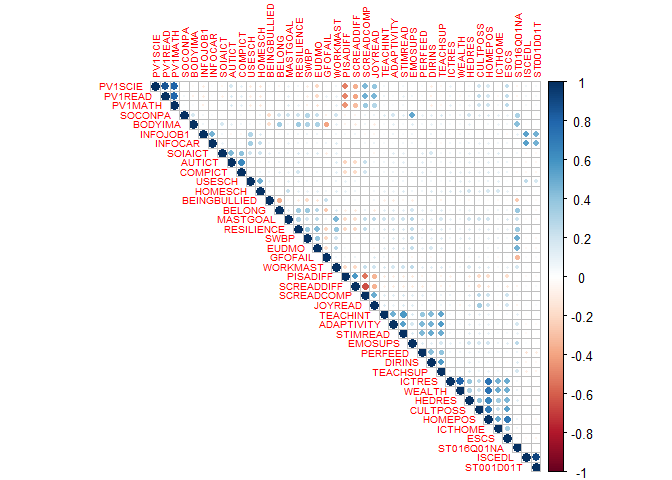

```r
correlation <- cor(IrlandaNoImput)

corrplot(correlation,
         type = "upper",
         tl.cex = 0.6,
         addshade = "positive") # show only upper part
```

## Teste de esfericidade de Bartlett em uma matriz de correlação.

O teste de esfericidade de Bartlett é um teste estatístico que avalia se as variáveis em um conjunto de dados estão correlacionadas entre si. Ele verifica a hipótese nula de que a matriz de correlação populacional é uma matriz de identidade, o que significa que as variáveis são independentes e não correlacionadas.

```r
cortest.bartlett(IrlandaNoImput)
```

```
## R was not square, finding R from data
```

```
## $chisq
## [1] 41336.28
##
## $p.value
## [1] 0
##
## $df
## [1] 820
```

Se o valor-p (p-value) calculado no teste de esfericidade de Bartlett for menor que 0.05, isso sugere evidências estatísticas para rejeitar a hipótese nula de que as variáveis são independentes e não correlacionadas, por outras palavras, existe uma correlação significativa entre as variáveis em questão. Isso significa que as variáveis não podem ser consideradas independentes, existindo algum grau de relação entre elas.

# Estandardizar os dados

```r
data_scaled <- scale(IrlandaNoImput)
data_scaled %>% glimpse()
```

```
##  num [1:2004, 1:41] 0.261 0.261 0.847 -1.74 1.008 ...
##  - attr(*, "dimnames")=List of 2
##   ..$ : NULL
##   ..$ : chr [1:41] "PV1SCIE" "PV1READ" "PV1MATH" "SOCONPA" ...
##  - attr(*, "scaled:center")= Named num [1:41] 526.975 551.952 525.029 0.213 -0.234 ...
##   ..- attr(*, "names")= chr [1:41] "PV1SCIE" "PV1READ" "PV1MATH" "SOCONPA" ...
##  - attr(*, "scaled:scale")= Named num [1:41] 80.192 82.634 70.972 0.888 0.907 ...
##   ..- attr(*, "names")= chr [1:41] "PV1SCIE" "PV1READ" "PV1MATH" "SOCONPA" ...
```

```r
# Dúvida: Estandardizamos os dados de variáveis que não têm distribuição normal?
```

# PCA

Nesta parte, passaremos então para o processo de criação de PCA’s. Podemos então começar por pensar algumas ideias por alto, podendo ser estas:

- **PCA de Desempenho Acadêmico**:
  - Variáveis de interesse: Pontuações em diferentes domínios acadêmicos, como leitura, matemática e ciências.
  - Objetivo: Compreender a estrutura subjacente do desempenho acadêmico dos alunos e identificar padrões gerais de habilidades e competências.
- **PCA de Fatores Socioeconômicos**:
  - Variáveis de interesse: Variáveis socioeconômicas, como o nível de educação dos pais, ocupação dos pais, renda familiar, acesso a recursos educacionais, etc.
  - Objetivo: Explorar as relações entre os fatores socioeconômicos e o desempenho acadêmico dos alunos, bem como identificar grupos de alunos com perfis socioeconômicos semelhantes.
- **PCA de Atitudes e Comportamentos**:
  - Variáveis de interesse: Variáveis relacionadas a atitudes, motivação, autoeficácia, disciplina, participação em atividades extracurriculares, etc.
  - Objetivo: Identificar padrões de atitudes e comportamentos dos alunos que podem influenciar seu desempenho académico e bem-estar geral.
- **PCA de Ambiente Escolar**:
  - Variáveis de interesse: Variáveis relacionadas ao ambiente escolar, como tamanho da turma, recursos educacionais disponíveis, clima escolar, relacionamento professor-aluno, etc.
  - Objetivo: Explorar a relação entre o ambiente escolar e o desempenho dos alunos, bem como identificar características importantes do ambiente que afetam o aprendizado.

## Criação do PCA

```r
dim(data_scaled)
```

```
## [1] 2004   41
```

```r
pc1 <- principal(data_scaled, nfactors=10, rotate="none")
```

### Kaiser Criterion

```r
valores <- round(pc1$values,3)
valores
```

```
##  [1] 5.986 4.241 3.413 2.932 2.702 2.077 1.683 1.199 1.095 1.037 0.955 0.942
## [13] 0.749 0.701 0.675 0.662 0.641 0.607 0.584 0.563 0.543 0.535 0.526 0.504
## [25] 0.493 0.471 0.457 0.450 0.442 0.427 0.408 0.390 0.369 0.344 0.320 0.299
## [37] 0.182 0.170 0.127 0.071 0.028
```

```r
length(valores[valores > 1])
```

```
## [1] 10
```

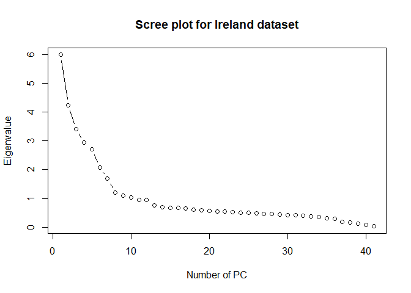

```r
plot(pc1$values, type = "b", main = "Scree plot for Ireland dataset",
     xlab = "Number of PC", ylab = "Eigenvalue")
```

Analisando o gráfico com atenção, é possível visualizar que existem várias quedas brutas, devido a isso, serão realizados vários testes com diferentes valores.

## PCA

Para uma melhor análise, é necessário ter conhecimento de algumas componentes e, para tal, de seguida teremos cada uma explicada de forma simples:

> SS loadings: Representa a soma dos quadrados das cargas dos componentes principais. Quanto maior o valor, mais bem os componentes capturam a variabilidade dos dados.

> Proportion Var: Indica a proporção da variância total explicada por cada componente principal. Quanto maior o valor, mais bem o componente explica a variabilidade dos dados em relação ao total.

> Cumulative Var: Representa a variância cumulativa explicada pelos componentes principais até o componente atual. É a soma acumulada das proporções de variância. Quanto maior o valor, mais bem os componentes principais explicam a variabilidade total dos dados à medida que adicionam-se mais componentes.

### Experiência com 6

```r
pc12 <- principal(data_scaled, nfactors = 6, rotate = "none")
pc12$loadings
```

```
##
## Loadings:
##              PC1    PC2    PC3    PC4    PC5    PC6
## PV1SCIE       0.365 -0.714 -0.241  0.114 -0.111
## PV1READ       0.397 -0.715 -0.271  0.123
## PV1MATH       0.380 -0.638 -0.183        -0.163
## SOCONPA       0.381  0.249               -0.205 -0.224
## BODYIMA       0.277  0.337               -0.461  0.144
## INFOJOB1             0.228  0.198  0.672
## INFOCAR       0.150         0.221  0.706
## SOIAICT       0.229  0.171                       0.690
## AUTICT        0.307 -0.127                       0.730
## COMPICT       0.308                              0.706
## USESCH        0.130  0.223  0.255  0.403  0.166  0.254
## HOMESCH       0.226  0.251  0.263  0.179  0.226  0.217
## BEINGBULLIED -0.131 -0.213  0.103         0.329  0.267
## BELONG        0.321  0.346 -0.133        -0.403
## MASTGOAL      0.482
## RESILIENCE    0.476  0.263 -0.165        -0.358  0.155
## SWBP          0.330  0.440               -0.374
## EUDMO         0.306  0.513               -0.303
## GFOFAIL             -0.251                0.457
## WORKMAST      0.459  0.113 -0.143  0.120
## PISADIFF     -0.465  0.455  0.294         0.139
## SCREADDIFF   -0.449  0.359  0.326         0.159
## SCREADCOMP    0.531 -0.413 -0.294  0.114
## JOYREAD       0.395 -0.422 -0.182  0.120  0.107 -0.159
## TEACHINT      0.425  0.232 -0.321         0.446 -0.177
## ADAPTIVITY    0.453  0.313 -0.307         0.397
## STIMREAD      0.466  0.245 -0.314         0.483
## EMOSUPS       0.423  0.207               -0.150 -0.219
## PERFEED       0.375  0.218 -0.245 -0.126  0.408
## DIRINS        0.368  0.388 -0.264         0.444
## TEACHSUP      0.411  0.353 -0.294 -0.101  0.434 -0.160
## ICTRES        0.471         0.626 -0.178
## WEALTH        0.407         0.676 -0.193
## HEDRES        0.535         0.397 -0.119
## CULTPOSS      0.523 -0.247  0.298               -0.134
## HOMEPOS       0.667 -0.172  0.637 -0.186        -0.116
## ICTHOME       0.351         0.530 -0.144
## ESCS          0.525 -0.261  0.476 -0.171        -0.138
## ST016Q01NA    0.342  0.457 -0.118        -0.468 -0.150
## ISCEDL                      0.177  0.882        -0.103
## ST001D01T                   0.136  0.836        -0.111
##
##                  PC1   PC2   PC3   PC4   PC5   PC6
## SS loadings    5.986 4.241 3.413 2.932 2.702 2.077
## Proportion Var 0.146 0.103 0.083 0.072 0.066 0.051
## Cumulative Var 0.146 0.249 0.333 0.404 0.470 0.521
```

```r
round(pc12$communality,2)
```

```
##      PV1SCIE      PV1READ      PV1MATH      SOCONPA      BODYIMA     INFOJOB1
##         0.73         0.77         0.62         0.30         0.43         0.55
##      INFOCAR      SOIAICT       AUTICT      COMPICT       USESCH      HOMESCH
##         0.59         0.57         0.65         0.60         0.39         0.31
## BEINGBULLIED       BELONG     MASTGOAL   RESILIENCE         SWBP        EUDMO
##         0.25         0.40         0.26         0.48         0.45         0.45
##      GFOFAIL     WORKMAST     PISADIFF   SCREADDIFF   SCREADCOMP      JOYREAD
##         0.29         0.27         0.54         0.47         0.56         0.42
##     TEACHINT   ADAPTIVITY     STIMREAD      EMOSUPS      PERFEED       DIRINS
##         0.57         0.57         0.62         0.30         0.43         0.56
##     TEACHSUP       ICTRES       WEALTH       HEDRES     CULTPOSS      HOMEPOS
##         0.61         0.66         0.66         0.46         0.45         0.93
##      ICTHOME         ESCS   ST016Q01NA       ISCEDL    ST001D01T
##         0.43         0.62         0.58         0.82         0.73
```

```r
# interessante
pc12r <- principal(data_scaled, nfactors= 6, rotate="varimax")
pc12r$loadings
```

```
##
## Loadings:
##              RC2    RC3    RC5    RC1    RC4    RC6
## PV1SCIE       0.841        -0.107
## PV1READ       0.869        -0.110
## PV1MATH       0.772  0.101
## SOCONPA              0.160  0.462  0.188        -0.144
## BODYIMA                     0.628                0.181
## INFOJOB1     -0.101         0.100         0.727
## INFOCAR                                   0.756
## SOIAICT                                          0.732
## AUTICT        0.229                              0.772
## COMPICT       0.173                              0.750
## USESCH       -0.172  0.133                0.495  0.291
## HOMESCH      -0.193  0.252         0.208  0.299  0.282
## BEINGBULLIED               -0.436                0.247
## BELONG                      0.627
## MASTGOAL      0.234  0.161  0.282  0.289  0.101
## RESILIENCE    0.173         0.615  0.117         0.234
## SWBP                        0.651
## EUDMO        -0.151         0.630  0.156
## GFOFAIL                    -0.508  0.139
## WORKMAST      0.229         0.321  0.257  0.120  0.146
## PISADIFF     -0.717                             -0.110
## SCREADDIFF   -0.643        -0.160               -0.136
## SCREADCOMP    0.712         0.104  0.141         0.145
## JOYREAD       0.591  0.115         0.189
## TEACHINT      0.104                0.742
## ADAPTIVITY                  0.137  0.736
## STIMREAD      0.102                0.775
## EMOSUPS       0.128  0.167  0.421  0.235        -0.129
## PERFEED                            0.634         0.130
## DIRINS                             0.730
## TEACHSUP                    0.115  0.766
## ICTRES               0.807
## WEALTH       -0.107  0.802
## HEDRES               0.643  0.137  0.153
## CULTPOSS      0.311  0.583         0.123
## HOMEPOS       0.181  0.943
## ICTHOME              0.634                       0.108
## ESCS          0.255  0.741
## ST016Q01NA                  0.751
## ISCEDL                            -0.119  0.883 -0.113
## ST001D01T                                 0.832 -0.122
##
##                  RC2   RC3   RC5   RC1   RC4   RC6
## SS loadings    4.468 4.148 3.749 3.748 2.994 2.244
## Proportion Var 0.109 0.101 0.091 0.091 0.073 0.055
## Cumulative Var 0.109 0.210 0.302 0.393 0.466 0.521
```

```r
round(pc12r$communality,2)
```

```
##      PV1SCIE      PV1READ      PV1MATH      SOCONPA      BODYIMA     INFOJOB1
##         0.73         0.77         0.62         0.30         0.43         0.55
##      INFOCAR      SOIAICT       AUTICT      COMPICT       USESCH      HOMESCH
##         0.59         0.57         0.65         0.60         0.39         0.31
## BEINGBULLIED       BELONG     MASTGOAL   RESILIENCE         SWBP        EUDMO
##         0.25         0.40         0.26         0.48         0.45         0.45
##      GFOFAIL     WORKMAST     PISADIFF   SCREADDIFF   SCREADCOMP      JOYREAD
##         0.29         0.27         0.54         0.47         0.56         0.42
##     TEACHINT   ADAPTIVITY     STIMREAD      EMOSUPS      PERFEED       DIRINS
##         0.57         0.57         0.62         0.30         0.43         0.56
##     TEACHSUP       ICTRES       WEALTH       HEDRES     CULTPOSS      HOMEPOS
##         0.61         0.66         0.66         0.46         0.45         0.93
##      ICTHOME         ESCS   ST016Q01NA       ISCEDL    ST001D01T
##         0.43         0.62         0.58         0.82         0.73
```

```r
pc12o <- principal(data_scaled, nfactors= 6, rotate="oblimin")
pc12o$loadings
```

```
##
## Loadings:
##              TC2    TC3    TC1    TC5    TC4    TC6
## PV1SCIE       0.844
## PV1READ       0.871
## PV1MATH       0.771        -0.107
## SOCONPA              0.144  0.151  0.451        -0.181
## BODYIMA                    -0.122  0.640         0.153
## INFOJOB1     -0.130                       0.720
## INFOCAR                                   0.752
## SOIAICT      -0.142                              0.734
## AUTICT        0.177                              0.780
## COMPICT       0.119                              0.755
## USESCH       -0.227  0.123                0.474  0.304
## HOMESCH      -0.255  0.240  0.191         0.272  0.278
## BEINGBULLIED                      -0.457         0.274
## BELONG                             0.632
## MASTGOAL      0.203  0.125  0.259  0.251
## RESILIENCE    0.156                0.609         0.206
## SWBP                               0.649
## EUDMO        -0.160                0.617
## GFOFAIL                     0.196 -0.538
## WORKMAST      0.201         0.221  0.295  0.111  0.126
## PISADIFF     -0.710               -0.106        -0.109
## SCREADDIFF   -0.638               -0.167        -0.130
## SCREADCOMP    0.694         0.121  0.101         0.141
## JOYREAD       0.577         0.205 -0.105
## TEACHINT                    0.759
## ADAPTIVITY                  0.738
## STIMREAD                    0.786
## EMOSUPS       0.115  0.146  0.203  0.404        -0.163
## PERFEED                     0.634        -0.108  0.105
## DIRINS       -0.116         0.733
## TEACHSUP                    0.773
## ICTRES               0.817
## WEALTH       -0.178  0.819
## HEDRES               0.636  0.115
## CULTPOSS      0.257  0.575  0.107
## HOMEPOS              0.946
## ICTHOME      -0.161  0.642
## ESCS          0.198  0.745
## ST016Q01NA                         0.760        -0.131
## ISCEDL                                    0.893
## ST001D01T                                 0.842
##
##                  TC2   TC3   TC1   TC5   TC4   TC6
## SS loadings    4.361 4.122 3.698 3.685 2.973 2.250
## Proportion Var 0.106 0.101 0.090 0.090 0.073 0.055
## Cumulative Var 0.106 0.207 0.297 0.387 0.459 0.514
```

```r
round(pc12o$communality,2)
```

```
##      PV1SCIE      PV1READ      PV1MATH      SOCONPA      BODYIMA     INFOJOB1
##         0.73         0.77         0.62         0.30         0.43         0.55
##      INFOCAR      SOIAICT       AUTICT      COMPICT       USESCH      HOMESCH
##         0.59         0.57         0.65         0.60         0.39         0.31
## BEINGBULLIED       BELONG     MASTGOAL   RESILIENCE         SWBP        EUDMO
##         0.25         0.40         0.26         0.48         0.45         0.45
##      GFOFAIL     WORKMAST     PISADIFF   SCREADDIFF   SCREADCOMP      JOYREAD
##         0.29         0.27         0.54         0.47         0.56         0.42
##     TEACHINT   ADAPTIVITY     STIMREAD      EMOSUPS      PERFEED       DIRINS
##         0.57         0.57         0.62         0.30         0.43         0.56
##     TEACHSUP       ICTRES       WEALTH       HEDRES     CULTPOSS      HOMEPOS
##         0.61         0.66         0.66         0.46         0.45         0.93
##      ICTHOME         ESCS   ST016Q01NA       ISCEDL    ST001D01T
##         0.43         0.62         0.58         0.82         0.73
```

```r
pc12pro <- principal(data_scaled, nfactors= 6, rotate="promax")
pc12pro$loadings
```

```
##
## Loadings:
##              RC2    RC3    RC1    RC5    RC4    RC6
## PV1SCIE       0.860        -0.102 -0.117
## PV1READ       0.884               -0.128
## PV1MATH       0.783        -0.142
## SOCONPA              0.130  0.132  0.449        -0.188
## BODYIMA                    -0.160  0.659         0.163
## INFOJOB1     -0.110                       0.723
## INFOCAR                                   0.752
## SOIAICT      -0.136                              0.743
## AUTICT        0.187                      -0.113  0.802
## COMPICT       0.128                      -0.117  0.775
## USESCH       -0.209                       0.445  0.274
## HOMESCH      -0.250  0.218  0.175         0.233  0.255
## BEINGBULLIED                      -0.465         0.272
## BELONG                             0.645
## MASTGOAL      0.185  0.101  0.237  0.236
## RESILIENCE    0.130                0.614         0.210
## SWBP         -0.118                0.663
## EUDMO        -0.195                0.633
## GFOFAIL                     0.220 -0.558
## WORKMAST      0.184         0.194  0.284         0.120
## PISADIFF     -0.710                             -0.120
## SCREADDIFF   -0.633               -0.142        -0.144
## SCREADCOMP    0.693                              0.148
## JOYREAD       0.580         0.191 -0.141
## TEACHINT                    0.784
## ADAPTIVITY                  0.759
## STIMREAD                    0.809
## EMOSUPS              0.129  0.183  0.398        -0.173
## PERFEED                     0.657        -0.140
## DIRINS       -0.149         0.759
## TEACHSUP                    0.803
## ICTRES               0.834
## WEALTH       -0.178  0.837 -0.104
## HEDRES               0.638
## CULTPOSS      0.257  0.580
## HOMEPOS              0.961
## ICTHOME      -0.162  0.652
## ESCS          0.200  0.763
## ST016Q01NA                         0.775        -0.131
## ISCEDL        0.120        -0.129         0.920 -0.125
## ST001D01T     0.106 -0.119                0.868 -0.133
##
##                  RC2   RC3   RC1   RC5   RC4   RC6
## SS loadings    4.434 4.249 3.909 3.820 3.062 2.336
## Proportion Var 0.108 0.104 0.095 0.093 0.075 0.057
## Cumulative Var 0.108 0.212 0.307 0.400 0.475 0.532
```

```r
round(pc12pro$communality,2)
```

```
##      PV1SCIE      PV1READ      PV1MATH      SOCONPA      BODYIMA     INFOJOB1
##         0.73         0.77         0.62         0.30         0.43         0.55
##      INFOCAR      SOIAICT       AUTICT      COMPICT       USESCH      HOMESCH
##         0.59         0.57         0.65         0.60         0.39         0.31
## BEINGBULLIED       BELONG     MASTGOAL   RESILIENCE         SWBP        EUDMO
##         0.25         0.40         0.26         0.48         0.45         0.45
##      GFOFAIL     WORKMAST     PISADIFF   SCREADDIFF   SCREADCOMP      JOYREAD
##         0.29         0.27         0.54         0.47         0.56         0.42
##     TEACHINT   ADAPTIVITY     STIMREAD      EMOSUPS      PERFEED       DIRINS
##         0.57         0.57         0.62         0.30         0.43         0.56
##     TEACHSUP       ICTRES       WEALTH       HEDRES     CULTPOSS      HOMEPOS
##         0.61         0.66         0.66         0.46         0.45         0.93
##      ICTHOME         ESCS   ST016Q01NA       ISCEDL    ST001D01T
##         0.43         0.62         0.58         0.82         0.73
```

```r
pc12qua <- principal(data_scaled, nfactors= 6, rotate="quartimin")
pc12qua$loadings
```

```
##
## Loadings:
##              TC2    TC3    TC1    TC5    TC4    TC6
## PV1SCIE       0.844
## PV1READ       0.871
## PV1MATH       0.771        -0.107
## SOCONPA              0.144  0.151  0.451        -0.181
## BODYIMA                    -0.122  0.640         0.153
## INFOJOB1     -0.130                       0.720
## INFOCAR                                   0.752
## SOIAICT      -0.142                              0.734
## AUTICT        0.177                              0.780
## COMPICT       0.119                              0.755
## USESCH       -0.227  0.123                0.474  0.304
## HOMESCH      -0.255  0.240  0.191         0.272  0.278
## BEINGBULLIED                      -0.457         0.274
## BELONG                             0.632
## MASTGOAL      0.203  0.125  0.259  0.251
## RESILIENCE    0.156                0.609         0.206
## SWBP                               0.649
## EUDMO        -0.160                0.617
## GFOFAIL                     0.196 -0.538
## WORKMAST      0.201         0.221  0.295  0.111  0.126
## PISADIFF     -0.710               -0.106        -0.109
## SCREADDIFF   -0.638               -0.167        -0.130
## SCREADCOMP    0.694         0.121  0.101         0.141
## JOYREAD       0.577         0.205 -0.105
## TEACHINT                    0.759
## ADAPTIVITY                  0.738
## STIMREAD                    0.786
## EMOSUPS       0.115  0.146  0.203  0.404        -0.163
## PERFEED                     0.634        -0.108  0.105
## DIRINS       -0.116         0.733
## TEACHSUP                    0.773
## ICTRES               0.817
## WEALTH       -0.178  0.819
## HEDRES               0.636  0.115
## CULTPOSS      0.257  0.575  0.107
## HOMEPOS              0.946
## ICTHOME      -0.161  0.642
## ESCS          0.198  0.745
## ST016Q01NA                         0.760        -0.131
## ISCEDL                                    0.893
## ST001D01T                                 0.842
##
##                  TC2   TC3   TC1   TC5   TC4   TC6
## SS loadings    4.361 4.122 3.698 3.685 2.973 2.250
## Proportion Var 0.106 0.101 0.090 0.090 0.073 0.055
## Cumulative Var 0.106 0.207 0.297 0.387 0.459 0.514
```

```r
round(pc12qua$communality,2)
```

```
##      PV1SCIE      PV1READ      PV1MATH      SOCONPA      BODYIMA     INFOJOB1
##         0.73         0.77         0.62         0.30         0.43         0.55
##      INFOCAR      SOIAICT       AUTICT      COMPICT       USESCH      HOMESCH
##         0.59         0.57         0.65         0.60         0.39         0.31
## BEINGBULLIED       BELONG     MASTGOAL   RESILIENCE         SWBP        EUDMO
##         0.25         0.40         0.26         0.48         0.45         0.45
##      GFOFAIL     WORKMAST     PISADIFF   SCREADDIFF   SCREADCOMP      JOYREAD
##         0.29         0.27         0.54         0.47         0.56         0.42
##     TEACHINT   ADAPTIVITY     STIMREAD      EMOSUPS      PERFEED       DIRINS
##         0.57         0.57         0.62         0.30         0.43         0.56
##     TEACHSUP       ICTRES       WEALTH       HEDRES     CULTPOSS      HOMEPOS
##         0.61         0.66         0.66         0.46         0.45         0.93
##      ICTHOME         ESCS   ST016Q01NA       ISCEDL    ST001D01T
##         0.43         0.62         0.58         0.82         0.73
```

```r
# Melhor

pc12equ <- principal(data_scaled, nfactors= 6, rotate="equamax")
pc12equ$loadings
```

```
##
## Loadings:
##              RC2    RC3    RC1    RC5    RC4    RC6
## PV1SCIE       0.843
## PV1READ       0.871
## PV1MATH       0.771  0.114
## SOCONPA              0.170  0.202  0.459        -0.128
## BODYIMA                            0.626         0.186
## INFOJOB1     -0.127                       0.722
## INFOCAR                                   0.752
## SOIAICT      -0.118                              0.733
## AUTICT        0.197                              0.780
## COMPICT       0.141                              0.756
## USESCH       -0.205  0.133                0.473  0.305
## HOMESCH      -0.223  0.249  0.204         0.273  0.292
## BEINGBULLIED                      -0.438         0.243
## BELONG                             0.625
## MASTGOAL      0.214  0.169  0.299  0.278
## RESILIENCE    0.148         0.127  0.612         0.254
## SWBP                        0.105  0.647
## EUDMO        -0.169         0.162  0.623
## GFOFAIL                     0.135 -0.510
## WORKMAST      0.206         0.266  0.318  0.112  0.170
## PISADIFF     -0.708               -0.104        -0.143
## SCREADDIFF   -0.634               -0.166        -0.165
## SCREADCOMP    0.698         0.155  0.109         0.181
## JOYREAD       0.587  0.126  0.204
## TEACHINT                    0.746
## ADAPTIVITY                  0.738  0.124
## STIMREAD                    0.777
## EMOSUPS       0.116  0.177  0.250  0.418        -0.109
## PERFEED                     0.628        -0.110  0.144
## DIRINS                      0.727                0.103
## TEACHSUP                    0.766  0.101
## ICTRES               0.807
## WEALTH       -0.124  0.800
## HEDRES               0.645  0.155  0.126
## CULTPOSS      0.297  0.589  0.130
## HOMEPOS       0.160  0.947
## ICTHOME      -0.118  0.632                       0.112
## ESCS          0.244  0.746
## ST016Q01NA                  0.101  0.749
## ISCEDL                                    0.893
## ST001D01T                                 0.841
##
##                  RC2   RC3   RC1   RC5   RC4   RC6
## SS loadings    4.391 4.184 3.781 3.695 2.974 2.324
## Proportion Var 0.107 0.102 0.092 0.090 0.073 0.057
## Cumulative Var 0.107 0.209 0.301 0.391 0.464 0.521
```

```r
round(pc12equ$communality,2)
```

```
##      PV1SCIE      PV1READ      PV1MATH      SOCONPA      BODYIMA     INFOJOB1
##         0.73         0.77         0.62         0.30         0.43         0.55
##      INFOCAR      SOIAICT       AUTICT      COMPICT       USESCH      HOMESCH
##         0.59         0.57         0.65         0.60         0.39         0.31
## BEINGBULLIED       BELONG     MASTGOAL   RESILIENCE         SWBP        EUDMO
##         0.25         0.40         0.26         0.48         0.45         0.45
##      GFOFAIL     WORKMAST     PISADIFF   SCREADDIFF   SCREADCOMP      JOYREAD
##         0.29         0.27         0.54         0.47         0.56         0.42
##     TEACHINT   ADAPTIVITY     STIMREAD      EMOSUPS      PERFEED       DIRINS
##         0.57         0.57         0.62         0.30         0.43         0.56
##     TEACHSUP       ICTRES       WEALTH       HEDRES     CULTPOSS      HOMEPOS
##         0.61         0.66         0.66         0.46         0.45         0.93
##      ICTHOME         ESCS   ST016Q01NA       ISCEDL    ST001D01T
##         0.43         0.62         0.58         0.82         0.73
```

### RC2 - Resultados escolares

- Esta componente principal tem em conta os resultados da avaliação do estudante nos três campos de conhecimento (ciências, leitura e matemática) bem como a dificuldade percepcionada pelo mesmo e, também, a sua percepção quer sobre dificuldade do teste, quer sobre a sua competência.

### RC3 - Estatuto socio-económico

- Esta componente principal tem em com conta as posses do estudante em casa bem como o seu estatuto económico, social e cultural. Esta componente principal também tem em atenção os recursos que o estudante tem quer em casa, quer no que diz respeito a ICT por si só.

### RC5 - Alegria e bem-estar interior

- Esta componente principal tem em conta a satisfação do estudante com a sua vida e o significado da mesma para si próprio. Esta componente principal também tem em conta os sentimentos positivos do estudante, sendo estes sentimentos como pertença, conforto com o seu corpo e a sua aparência, ausência de receio de falhar, resiliência e bom relacionamento com os pais.

### RC1 - Apoio por parte do professor

- Esta componente principal tem em conta a percepção do estudante quer no que diz respeito interesse do professor, quer no que diz respeito ao estímulo proveniente do mesmo para que os estudantes leiam. Esta componente principal também tem em conta a adaptabilidade do ensino do professor e apoio deste em aulas sobre línguas.

### RC4 - Nível de educação e informação sobre carreiras

- Esta componente principal tem em conta o nível de educação do estudante e a informação que este tem sobre carreiras a seguir. No que diz respeito à informação que estudante tem sobre carreiras a seguir tem-se em conta a informação que o mesmo tem em geral e, também, a informação sobre este tema que lhe foi fornecida pela escola.

### RC6 - Manuseamento de ICT

- Esta componente principal tem em conta o uso de ICT por parte do estudante no que diz respeito a integração social bem como a autonomia do mesmo com estas tecnologias. Esta componente principal também tem em conta a percepção de competência relativamente ao manuseamento de ICT por parte do estudante.

> Comparativamente ao ficheiro com Imputação, o RC5 e o RC1 estão ao contrário

### Experiência com 7

```r
pc7 <- principal(data_scaled, nfactors = 7, rotate = "none")
pc7$loadings
```

```
##
## Loadings:
##              PC1    PC2    PC3    PC4    PC5    PC6    PC7
## PV1SCIE       0.365 -0.714 -0.241  0.114 -0.111        -0.189
## PV1READ       0.397 -0.715 -0.271  0.123               -0.101
## PV1MATH       0.380 -0.638 -0.183        -0.163        -0.212
## SOCONPA       0.381  0.249               -0.205 -0.224  0.174
## BODYIMA       0.277  0.337               -0.461  0.144 -0.225
## INFOJOB1             0.228  0.198  0.672
## INFOCAR       0.150         0.221  0.706
## SOIAICT       0.229  0.171                       0.690
## AUTICT        0.307 -0.127                       0.730 -0.115
## COMPICT       0.308                              0.706
## USESCH        0.130  0.223  0.255  0.403  0.166  0.254  0.173
## HOMESCH       0.226  0.251  0.263  0.179  0.226  0.217  0.326
## BEINGBULLIED -0.131 -0.213  0.103         0.329  0.267  0.271
## BELONG        0.321  0.346 -0.133        -0.403        -0.180
## MASTGOAL      0.482                                     0.481
## RESILIENCE    0.476  0.263 -0.165        -0.358  0.155  0.118
## SWBP          0.330  0.440               -0.374
## EUDMO         0.306  0.513               -0.303         0.188
## GFOFAIL             -0.251                0.457         0.374
## WORKMAST      0.459  0.113 -0.143  0.120                0.427
## PISADIFF     -0.465  0.455  0.294         0.139
## SCREADDIFF   -0.449  0.359  0.326         0.159
## SCREADCOMP    0.531 -0.413 -0.294  0.114                0.117
## JOYREAD       0.395 -0.422 -0.182  0.120  0.107 -0.159  0.331
## TEACHINT      0.425  0.232 -0.321         0.446 -0.177 -0.138
## ADAPTIVITY    0.453  0.313 -0.307         0.397        -0.213
## STIMREAD      0.466  0.245 -0.314         0.483        -0.125
## EMOSUPS       0.423  0.207               -0.150 -0.219  0.268
## PERFEED       0.375  0.218 -0.245 -0.126  0.408        -0.170
## DIRINS        0.368  0.388 -0.264         0.444        -0.156
## TEACHSUP      0.411  0.353 -0.294 -0.101  0.434 -0.160 -0.176
## ICTRES        0.471         0.626 -0.178               -0.194
## WEALTH        0.407         0.676 -0.193               -0.233
## HEDRES        0.535         0.397 -0.119
## CULTPOSS      0.523 -0.247  0.298               -0.134  0.192
## HOMEPOS       0.667 -0.172  0.637 -0.186        -0.116
## ICTHOME       0.351         0.530 -0.144               -0.172
## ESCS          0.525 -0.261  0.476 -0.171        -0.138
## ST016Q01NA    0.342  0.457 -0.118        -0.468 -0.150
## ISCEDL                      0.177  0.882        -0.103 -0.207
## ST001D01T                   0.136  0.836        -0.111 -0.234
##
##                  PC1   PC2   PC3   PC4   PC5   PC6   PC7
## SS loadings    5.986 4.241 3.413 2.932 2.702 2.077 1.683
## Proportion Var 0.146 0.103 0.083 0.072 0.066 0.051 0.041
## Cumulative Var 0.146 0.249 0.333 0.404 0.470 0.521 0.562
```

```r
round(pc7$communality,2)
```

```
##      PV1SCIE      PV1READ      PV1MATH      SOCONPA      BODYIMA     INFOJOB1
##         0.76         0.78         0.66         0.33         0.48         0.56
##      INFOCAR      SOIAICT       AUTICT      COMPICT       USESCH      HOMESCH
##         0.59         0.57         0.67         0.61         0.42         0.42
## BEINGBULLIED       BELONG     MASTGOAL   RESILIENCE         SWBP        EUDMO
##         0.33         0.44         0.49         0.50         0.45         0.49
##      GFOFAIL     WORKMAST     PISADIFF   SCREADDIFF   SCREADCOMP      JOYREAD
##         0.43         0.45         0.54         0.47         0.58         0.53
##     TEACHINT   ADAPTIVITY     STIMREAD      EMOSUPS      PERFEED       DIRINS
##         0.59         0.61         0.63         0.37         0.46         0.58
##     TEACHSUP       ICTRES       WEALTH       HEDRES     CULTPOSS      HOMEPOS
##         0.64         0.69         0.72         0.47         0.49         0.93
##      ICTHOME         ESCS   ST016Q01NA       ISCEDL    ST001D01T
##         0.46         0.62         0.59         0.86         0.79
```

```r
pc7r <- principal(data_scaled, nfactors= 7, rotate="varimax")
pc7r$loadings
```

```
##
## Loadings:
##              RC2    RC3    RC5    RC7    RC4    RC1    RC6
## PV1SCIE       0.861                             -0.105
## PV1READ       0.875               -0.101
## PV1MATH       0.794  0.131                      -0.111
## SOCONPA              0.128  0.124  0.349         0.390 -0.158
## BODYIMA                            0.665                0.188
## INFOJOB1     -0.113                       0.730
## INFOCAR                                   0.739  0.168
## SOIAICT                                                 0.732
## AUTICT        0.236                                     0.775
## COMPICT       0.174                                     0.751
## USESCH       -0.215  0.101                0.451  0.256  0.285
## HOMESCH      -0.255  0.196        -0.133  0.230  0.407  0.265
## BEINGBULLIED                      -0.502         0.101  0.236
## BELONG                             0.641
## MASTGOAL      0.150         0.134                0.661
## RESILIENCE    0.139                0.513         0.398  0.224
## SWBP         -0.102                0.577         0.315
## EUDMO        -0.189                0.516         0.418
## GFOFAIL                           -0.620         0.209
## WORKMAST      0.153         0.118  0.119         0.616  0.121
## PISADIFF     -0.713                             -0.102 -0.112
## SCREADDIFF   -0.632               -0.118        -0.168 -0.133
## SCREADCOMP    0.681                              0.286  0.137
## JOYREAD       0.535               -0.242         0.402 -0.105
## TEACHINT                    0.749                0.111
## ADAPTIVITY                  0.763  0.132
## STIMREAD                    0.776                0.136
## EMOSUPS              0.120  0.142  0.273         0.483 -0.147
## PERFEED                     0.655                       0.132
## DIRINS                      0.742
## TEACHSUP                    0.783  0.102
## ICTRES               0.826
## WEALTH               0.827
## HEDRES               0.620  0.109                0.260
## CULTPOSS      0.269  0.546        -0.130         0.314
## HOMEPOS       0.164  0.937                       0.156
## ICTHOME              0.651                              0.113
## ESCS          0.245  0.737                       0.108
## ST016Q01NA                         0.717         0.228
## ISCEDL        0.101                       0.910
## ST001D01T                                 0.864 -0.124 -0.101
##
##                  RC2   RC3   RC5   RC7   RC4   RC1   RC6
## SS loadings    4.362 4.061 3.530 3.296 2.948 2.608 2.228
## Proportion Var 0.106 0.099 0.086 0.080 0.072 0.064 0.054
## Cumulative Var 0.106 0.205 0.292 0.372 0.444 0.507 0.562
```

```r
round(pc7r$communality,2)
```

```
##      PV1SCIE      PV1READ      PV1MATH      SOCONPA      BODYIMA     INFOJOB1
##         0.76         0.78         0.66         0.33         0.48         0.56
##      INFOCAR      SOIAICT       AUTICT      COMPICT       USESCH      HOMESCH
##         0.59         0.57         0.67         0.61         0.42         0.42
## BEINGBULLIED       BELONG     MASTGOAL   RESILIENCE         SWBP        EUDMO
##         0.33         0.44         0.49         0.50         0.45         0.49
##      GFOFAIL     WORKMAST     PISADIFF   SCREADDIFF   SCREADCOMP      JOYREAD
##         0.43         0.45         0.54         0.47         0.58         0.53
##     TEACHINT   ADAPTIVITY     STIMREAD      EMOSUPS      PERFEED       DIRINS
##         0.59         0.61         0.63         0.37         0.46         0.58
##     TEACHSUP       ICTRES       WEALTH       HEDRES     CULTPOSS      HOMEPOS
##         0.64         0.69         0.72         0.47         0.49         0.93
##      ICTHOME         ESCS   ST016Q01NA       ISCEDL    ST001D01T
##         0.46         0.62         0.59         0.86         0.79
```

```r
pc7o <- principal(data_scaled, nfactors= 7, rotate="oblimin")
pc7o$loadings
```

```
##
## Loadings:
##              TC2    TC3    TC1    TC5    TC4    TC7    TC6
## PV1SCIE       0.867
## PV1READ       0.874
## PV1MATH       0.800                             -0.112
## SOCONPA              0.109         0.385         0.305 -0.194
## BODYIMA                            0.664        -0.114  0.177
## INFOJOB1     -0.135                       0.721
## INFOCAR                                   0.720  0.193
## SOIAICT      -0.138                                     0.731
## AUTICT        0.192                                     0.785
## COMPICT       0.127                                     0.755
## USESCH       -0.278                       0.411  0.274  0.280
## HOMESCH      -0.335  0.173        -0.127  0.176  0.416  0.240
## BEINGBULLIED                      -0.497         0.209  0.245
## BELONG                             0.643
## MASTGOAL                           0.120         0.637
## RESILIENCE    0.108                0.550         0.294  0.197
## SWBP         -0.112                0.605         0.194
## EUDMO        -0.213                0.549         0.310
## GFOFAIL                           -0.605         0.328
## WORKMAST                           0.175         0.587
## PISADIFF     -0.700                                    -0.116
## SCREADDIFF   -0.616               -0.145        -0.141 -0.131
## SCREADCOMP    0.645                              0.276  0.132
## JOYREAD       0.488               -0.191         0.445 -0.118
## TEACHINT                    0.768
## ADAPTIVITY                  0.776
## STIMREAD                    0.789
## EMOSUPS                            0.317         0.412 -0.186
## PERFEED                     0.663                       0.111
## DIRINS       -0.109         0.753
## TEACHSUP                    0.799
## ICTRES               0.838                      -0.114
## WEALTH       -0.132  0.848                      -0.169
## HEDRES               0.608                       0.199
## CULTPOSS      0.203  0.525        -0.113         0.305
## HOMEPOS              0.934
## ICTHOME      -0.128  0.663                      -0.110
## ESCS          0.196  0.735
## ST016Q01NA                         0.740               -0.120
## ISCEDL                                    0.922
## ST001D01T                                 0.879
##
##                  TC2   TC3   TC1   TC5   TC4   TC7   TC6
## SS loadings    4.223 4.014 3.537 3.426 2.906 2.241 2.221
## Proportion Var 0.103 0.098 0.086 0.084 0.071 0.055 0.054
## Cumulative Var 0.103 0.201 0.287 0.371 0.442 0.496 0.550
```

```r
round(pc7o$communality,2)
```

```
##      PV1SCIE      PV1READ      PV1MATH      SOCONPA      BODYIMA     INFOJOB1
##         0.76         0.78         0.66         0.33         0.48         0.56
##      INFOCAR      SOIAICT       AUTICT      COMPICT       USESCH      HOMESCH
##         0.59         0.57         0.67         0.61         0.42         0.42
## BEINGBULLIED       BELONG     MASTGOAL   RESILIENCE         SWBP        EUDMO
##         0.33         0.44         0.49         0.50         0.45         0.49
##      GFOFAIL     WORKMAST     PISADIFF   SCREADDIFF   SCREADCOMP      JOYREAD
##         0.43         0.45         0.54         0.47         0.58         0.53
##     TEACHINT   ADAPTIVITY     STIMREAD      EMOSUPS      PERFEED       DIRINS
##         0.59         0.61         0.63         0.37         0.46         0.58
##     TEACHSUP       ICTRES       WEALTH       HEDRES     CULTPOSS      HOMEPOS
##         0.64         0.69         0.72         0.47         0.49         0.93
##      ICTHOME         ESCS   ST016Q01NA       ISCEDL    ST001D01T
##         0.46         0.62         0.59         0.86         0.79
```

```r
pc7pro <- principal(data_scaled, nfactors= 7, rotate="promax")
pc7pro$loadings
```

```
##
## Loadings:
##              RC2    RC3    RC5    RC7    RC4    RC1    RC6
## PV1SCIE       0.885                       0.107 -0.111
## PV1READ       0.882
## PV1MATH       0.818  0.117                      -0.126
## SOCONPA                            0.319         0.393 -0.208
## BODYIMA                            0.673                0.191
## INFOJOB1                                  0.725
## INFOCAR                                   0.712  0.162
## SOIAICT      -0.119                                     0.734
## AUTICT        0.210                                     0.800
## COMPICT       0.141                      -0.101         0.768
## USESCH       -0.257               -0.113  0.367  0.258  0.243
## HOMESCH      -0.343  0.119        -0.179  0.113  0.419  0.203
## BEINGBULLIED                      -0.512         0.151  0.229
## BELONG                             0.638
## MASTGOAL                                         0.717
## RESILIENCE                         0.495         0.400  0.189
## SWBP         -0.137                0.558         0.302
## EUDMO        -0.248                0.485         0.423
## GFOFAIL                           -0.646         0.270
## WORKMAST            -0.107                       0.668
## PISADIFF     -0.699                             -0.103 -0.126
## SCREADDIFF   -0.604               -0.121        -0.179 -0.140
## SCREADCOMP    0.630                              0.310  0.129
## JOYREAD       0.458               -0.263         0.461 -0.137
## TEACHINT                    0.763
## ADAPTIVITY                  0.774
## STIMREAD                    0.780
## EMOSUPS                            0.236         0.501 -0.207
## PERFEED                     0.664                       0.120
## DIRINS       -0.109         0.750
## TEACHSUP                    0.798
## ICTRES               0.856                      -0.149
## WEALTH       -0.103  0.872                      -0.203
## HEDRES               0.588                       0.211
## CULTPOSS      0.189  0.498        -0.161         0.305
## HOMEPOS       0.101  0.931
## ICTHOME      -0.106  0.677                      -0.132
## ESCS          0.199  0.736
## ST016Q01NA                         0.706         0.197 -0.119
## ISCEDL        0.175                       0.955 -0.115
## ST001D01T     0.170                       0.914 -0.152
##
##                  RC2   RC3   RC5   RC7   RC4   RC1   RC6
## SS loadings    4.256 4.042 3.469 3.213 3.020 2.854 2.266
## Proportion Var 0.104 0.099 0.085 0.078 0.074 0.070 0.055
## Cumulative Var 0.104 0.202 0.287 0.365 0.439 0.509 0.564
```

```r
round(pc7pro$communality,2)
```

```
##      PV1SCIE      PV1READ      PV1MATH      SOCONPA      BODYIMA     INFOJOB1
##         0.76         0.78         0.66         0.33         0.48         0.56
##      INFOCAR      SOIAICT       AUTICT      COMPICT       USESCH      HOMESCH
##         0.59         0.57         0.67         0.61         0.42         0.42
## BEINGBULLIED       BELONG     MASTGOAL   RESILIENCE         SWBP        EUDMO
##         0.33         0.44         0.49         0.50         0.45         0.49
##      GFOFAIL     WORKMAST     PISADIFF   SCREADDIFF   SCREADCOMP      JOYREAD
##         0.43         0.45         0.54         0.47         0.58         0.53
##     TEACHINT   ADAPTIVITY     STIMREAD      EMOSUPS      PERFEED       DIRINS
##         0.59         0.61         0.63         0.37         0.46         0.58
##     TEACHSUP       ICTRES       WEALTH       HEDRES     CULTPOSS      HOMEPOS
##         0.64         0.69         0.72         0.47         0.49         0.93
##      ICTHOME         ESCS   ST016Q01NA       ISCEDL    ST001D01T
##         0.46         0.62         0.59         0.86         0.79
```

```r
pc7qua <- principal(data_scaled, nfactors= 7, rotate="quartimin")
pc7qua$loadings
```

```
##
## Loadings:
##              TC2    TC3    TC1    TC5    TC4    TC7    TC6
## PV1SCIE       0.867
## PV1READ       0.874
## PV1MATH       0.800                             -0.112
## SOCONPA              0.109         0.385         0.305 -0.194
## BODYIMA                            0.664        -0.114  0.177
## INFOJOB1     -0.135                       0.721
## INFOCAR                                   0.720  0.193
## SOIAICT      -0.138                                     0.731
## AUTICT        0.192                                     0.785
## COMPICT       0.127                                     0.755
## USESCH       -0.278                       0.411  0.274  0.280
## HOMESCH      -0.335  0.173        -0.127  0.176  0.416  0.240
## BEINGBULLIED                      -0.497         0.209  0.245
## BELONG                             0.643
## MASTGOAL                           0.120         0.637
## RESILIENCE    0.108                0.550         0.294  0.197
## SWBP         -0.112                0.605         0.194
## EUDMO        -0.213                0.549         0.310
## GFOFAIL                           -0.605         0.328
## WORKMAST                           0.175         0.587
## PISADIFF     -0.700                                    -0.116
## SCREADDIFF   -0.616               -0.145        -0.141 -0.131
## SCREADCOMP    0.645                              0.276  0.132
## JOYREAD       0.488               -0.191         0.445 -0.118
## TEACHINT                    0.768
## ADAPTIVITY                  0.776
## STIMREAD                    0.789
## EMOSUPS                            0.317         0.412 -0.186
## PERFEED                     0.663                       0.111
## DIRINS       -0.109         0.753
## TEACHSUP                    0.799
## ICTRES               0.838                      -0.114
## WEALTH       -0.132  0.848                      -0.169
## HEDRES               0.608                       0.199
## CULTPOSS      0.203  0.525        -0.113         0.305
## HOMEPOS              0.934
## ICTHOME      -0.128  0.663                      -0.110
## ESCS          0.196  0.735
## ST016Q01NA                         0.740               -0.120
## ISCEDL                                    0.922
## ST001D01T                                 0.879
##
##                  TC2   TC3   TC1   TC5   TC4   TC7   TC6
## SS loadings    4.223 4.014 3.537 3.426 2.906 2.241 2.221
## Proportion Var 0.103 0.098 0.086 0.084 0.071 0.055 0.054
## Cumulative Var 0.103 0.201 0.287 0.371 0.442 0.496 0.550
```

```r
round(pc7qua$communality,2)
```

```
##      PV1SCIE      PV1READ      PV1MATH      SOCONPA      BODYIMA     INFOJOB1
##         0.76         0.78         0.66         0.33         0.48         0.56
##      INFOCAR      SOIAICT       AUTICT      COMPICT       USESCH      HOMESCH
##         0.59         0.57         0.67         0.61         0.42         0.42
## BEINGBULLIED       BELONG     MASTGOAL   RESILIENCE         SWBP        EUDMO
##         0.33         0.44         0.49         0.50         0.45         0.49
##      GFOFAIL     WORKMAST     PISADIFF   SCREADDIFF   SCREADCOMP      JOYREAD
##         0.43         0.45         0.54         0.47         0.58         0.53
##     TEACHINT   ADAPTIVITY     STIMREAD      EMOSUPS      PERFEED       DIRINS
##         0.59         0.61         0.63         0.37         0.46         0.58
##     TEACHSUP       ICTRES       WEALTH       HEDRES     CULTPOSS      HOMEPOS
##         0.64         0.69         0.72         0.47         0.49         0.93
##      ICTHOME         ESCS   ST016Q01NA       ISCEDL    ST001D01T
##         0.46         0.62         0.59         0.86         0.79
```

```r
pc7equ <- principal(data_scaled, nfactors= 7, rotate="equamax")
pc7equ$loadings
```

```
##
## Loadings:
##              RC2    RC3    RC1    RC5    RC4    RC7    RC6
## PV1SCIE       0.865
## PV1READ       0.875
## PV1MATH       0.797  0.134
## SOCONPA              0.132  0.137  0.376         0.362 -0.151
## BODYIMA                            0.661                0.199
## INFOJOB1     -0.134                       0.724
## INFOCAR                                   0.727  0.203
## SOIAICT      -0.123                                     0.732
## AUTICT        0.203                                     0.786
## COMPICT       0.141                                     0.759
## USESCH       -0.253                       0.425  0.269  0.286
## HOMESCH      -0.297  0.191        -0.113  0.195  0.411  0.258
## BEINGBULLIED                      -0.495         0.138  0.224
## BELONG                      0.109  0.642
## MASTGOAL      0.107         0.141  0.106         0.662
## RESILIENCE    0.102                0.537         0.369  0.235
## SWBP         -0.123                0.596         0.264
## EUDMO        -0.219                0.541         0.365
## GFOFAIL                           -0.603         0.254
## WORKMAST      0.108         0.124  0.161         0.615  0.126
## PISADIFF     -0.699                             -0.139 -0.144
## SCREADDIFF   -0.615               -0.132        -0.194 -0.160
## SCREADCOMP    0.655                              0.325  0.166
## JOYREAD       0.513               -0.209         0.449
## TEACHINT                    0.752                0.109
## ADAPTIVITY                  0.765  0.121
## STIMREAD                    0.777                0.136
## EMOSUPS              0.122  0.156  0.307         0.463 -0.140
## PERFEED                     0.651                       0.147
## DIRINS                      0.742                       0.102
## TEACHSUP                    0.785
## ICTRES               0.826
## WEALTH               0.828                      -0.101
## HEDRES               0.619  0.112                0.259
## CULTPOSS      0.249  0.545        -0.109         0.340
## HOMEPOS       0.149  0.936                       0.168
## ICTHOME              0.651                              0.120
## ESCS          0.238  0.737                       0.124
## ST016Q01NA                  0.108  0.730         0.170
## ISCEDL                                    0.919
## ST001D01T                                 0.874
##
##                  RC2   RC3   RC1   RC5   RC4   RC7   RC6
## SS loadings    4.260 4.056 3.558 3.380 2.920 2.574 2.286
## Proportion Var 0.104 0.099 0.087 0.082 0.071 0.063 0.056
## Cumulative Var 0.104 0.203 0.290 0.372 0.443 0.506 0.562
```

```r
round(pc12equ$communality,2)
```

```
##      PV1SCIE      PV1READ      PV1MATH      SOCONPA      BODYIMA     INFOJOB1
##         0.73         0.77         0.62         0.30         0.43         0.55
##      INFOCAR      SOIAICT       AUTICT      COMPICT       USESCH      HOMESCH
##         0.59         0.57         0.65         0.60         0.39         0.31
## BEINGBULLIED       BELONG     MASTGOAL   RESILIENCE         SWBP        EUDMO
##         0.25         0.40         0.26         0.48         0.45         0.45
##      GFOFAIL     WORKMAST     PISADIFF   SCREADDIFF   SCREADCOMP      JOYREAD
##         0.29         0.27         0.54         0.47         0.56         0.42
##     TEACHINT   ADAPTIVITY     STIMREAD      EMOSUPS      PERFEED       DIRINS
##         0.57         0.57         0.62         0.30         0.43         0.56
##     TEACHSUP       ICTRES       WEALTH       HEDRES     CULTPOSS      HOMEPOS
##         0.61         0.66         0.66         0.46         0.45         0.93
##      ICTHOME         ESCS   ST016Q01NA       ISCEDL    ST001D01T
##         0.43         0.62         0.58         0.82         0.73
```

```r
pc6sc <- principal(data_scaled, nfactors = 6, rotate = "equamax", scores = TRUE)
round(pc6sc$scores,3)
```

```
##            RC2    RC3    RC1    RC5    RC4    RC6
##    [1,]  0.713  0.256  1.936 -0.275  1.675 -1.296
##    [2,] -1.107  1.622 -0.488 -1.086  0.581 -0.807
##    [3,] -0.140 -0.507 -0.731  0.360 -0.892  1.006
##    [4,] -2.031  1.185 -0.070  0.852  1.372 -0.200
##    [5,]  0.692 -0.115  0.789  0.299  1.135 -1.517
##    [6,]  1.076  2.208  0.734  0.157 -0.729  1.588
##    [7,]  1.081  0.625  0.749  1.475  1.223 -1.687
##    [8,]  0.864  0.795 -0.362 -0.449  1.223 -0.877
##    [9,]  0.712  0.193 -1.046  0.050 -1.148 -1.600
##   [10,]  0.468 -0.229 -1.268 -0.102 -0.813 -0.248
##   [11,]  2.301  0.477  1.130  0.674  1.413 -1.352
##   [12,]  0.552  0.158  0.311 -0.701 -0.674 -0.477
##   [13,] -0.062  0.467  0.800  0.460  1.564 -0.846
##   [14,] -0.031 -1.472  0.053 -1.887  1.021  0.859
```

[output cut: 1990 more lines]

```r
mean(pc6sc$scores[,1])
```

```
## [1] -2.34878e-18
```

```r
sd(pc6sc$scores[,1])
```

```
## [1] 1
```

```r
IrlandaNoImput$Intelligence <- pc6sc$scores[,1] # RC2 - Resultados Escolares
IrlandaNoImput$Socioeconomic <- pc6sc$scores[,2] # RC3 - Estatuto socio-económico
IrlandaNoImput$SchoolSupport <- pc6sc$scores[,3] # RC1 - Apoio por parte do professor
IrlandaNoImput$Hapiness <- pc6sc$scores[,4] # RC5 - Alegria e bem-estar interior
IrlandaNoImput$CareerAwareness <- pc6sc$scores[,5] # RC4 - Nível de educação e informação sobre carreiras
IrlandaNoImput$ICTKnowledge <- pc6sc$scores[,6] # RC6 - Manuseamento de ICT
```

```r
dim(IrlandaNoImput)
```

```
## [1] 2004   47
```

```r
IrlandaNoImput[,43:47]
```

```
## # A tibble: 2,004 × 5
##    Socioeconomic SchoolSupport Hapiness CareerAwareness ICTKnowledge
##            <dbl>         <dbl>    <dbl>           <dbl>        <dbl>
##  1         0.256        1.94    -0.275            1.67        -1.30
##  2         1.62        -0.488   -1.09             0.581       -0.807
##  3        -0.507       -0.731    0.360           -0.892        1.01
##  4         1.18        -0.0703   0.852            1.37        -0.200
##  5        -0.115        0.789    0.299            1.13        -1.52
##  6         2.21         0.734    0.157           -0.729        1.59
##  7         0.625        0.749    1.48             1.22        -1.69
##  8         0.795       -0.362   -0.449            1.22        -0.877
##  9         0.193       -1.05     0.0498          -1.15        -1.60
## 10        -0.229       -1.27    -0.102           -0.813       -0.248
## # ℹ 1,994 more rows
```

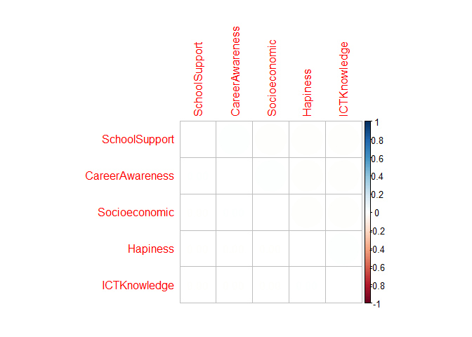

```r
corr <- cor(IrlandaNoImput[,43:47])
par(oma = c(2, 2, 2, 2))   # space rounf the graph
corrplot.mixed(corr,
        order = "hclust",
        tl.pos = "lt",
        upper = "ellipse")
```

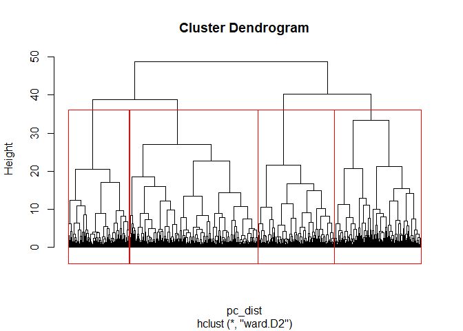

```r
pc_dist <- dist(IrlandaNoImput[,43:47])
hclust  <- hclust(pc_dist, method='ward.D2')
plot(hclust, hang=-1, labels=FALSE)

groups.k5 <- cutree(hclust, k = 4)
rect.hclust(hclust, k = 4, border="red")
```

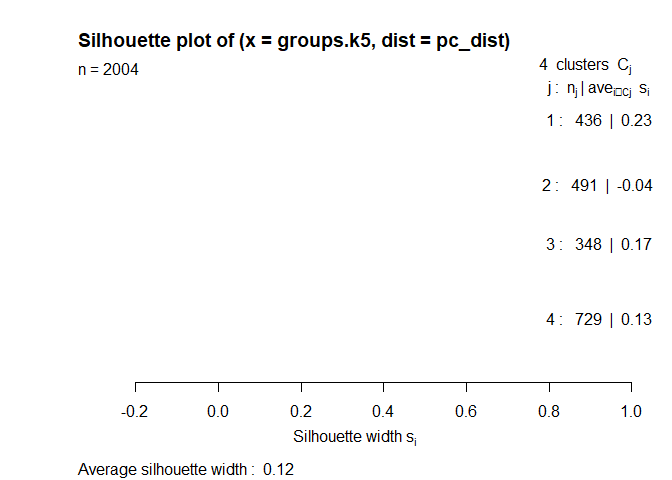

```r
# 4 ou 5 clusters?
plot(silhouette(groups.k5, pc_dist))
```

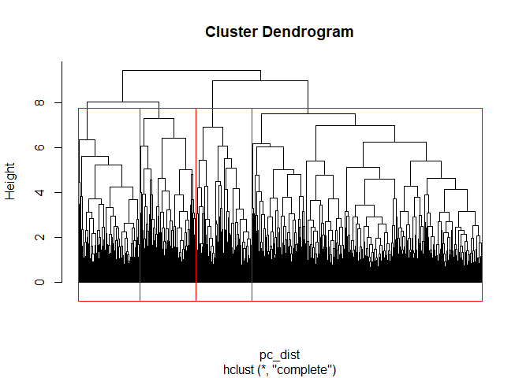

```r
pc_dist <- dist(IrlandaNoImput[,43:47])
hclust  <- hclust(pc_dist, method='complete')
plot(hclust, hang=-1, labels=FALSE)

groups.k5_c <- cutree(hclust, k=4)
rect.hclust(hclust, k=4, border="red")
```

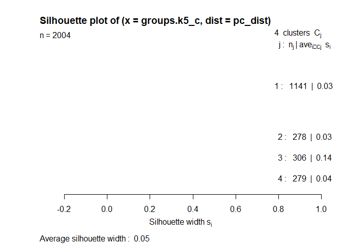

```r
plot(silhouette(groups.k5_c, pc_dist))
```

```r
table(groups.k5,groups.k5_c)
```

```
##          groups.k5_c
## groups.k5   1   2   3   4
##         1 246   4 137  49
##         2 108 155  63 165
##         3 264   5  51  28
##         4 523 114  55  37
```

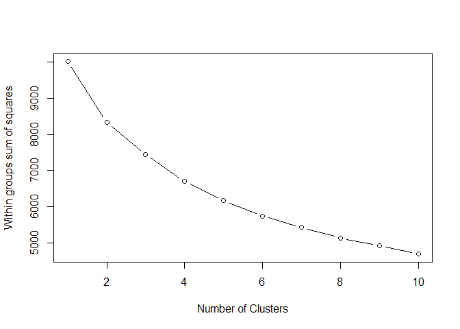

```r
# K-Means: number of clusters
wssplot <- function(xx, nc=15, seed=1234){
  wss <- (nrow(xx)-1)*sum(apply(xx,2,var))
  for (i in 2:nc){
    set.seed(seed)
    wss[i] <- sum(kmeans(xx, centers=i)$withinss)}
  plot(1:nc, wss, type="b", xlab="Number of Clusters",
       ylab="Within groups sum of squares")}
wssplot(IrlandaNoImput[,43:47], nc=10)
```

```r
#K-means cluster com K=4
kmeans.k6 <- kmeans(IrlandaNoImput[,43:47], 4, nstart=100)
IrlandaNoImput = IrlandaNoImput %>% mutate(cluster = kmeans.k6$cluster)
```

```r
table(groups.k5, IrlandaNoImput$cluster)
```

```
##
## groups.k5   1   2   3   4
##         1  10   4   5 417
##         2  56  20 272 143
##         3 302  30  10   6
##         4  63 575  59  32
```

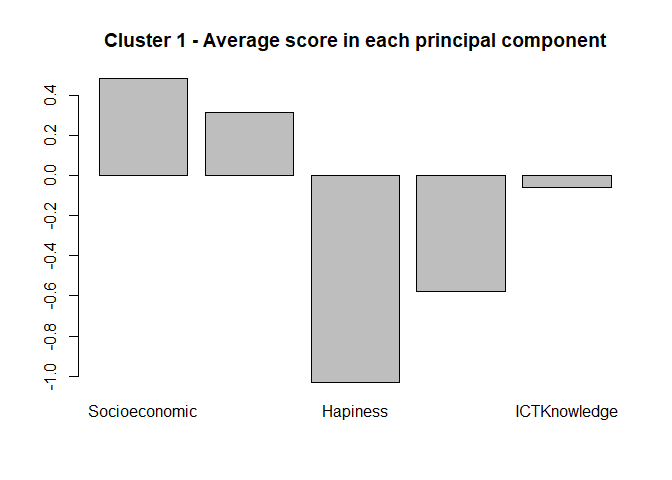

```r
#Barplot of average score in each principal component within each cluster
barplot(colMeans(subset(IrlandaNoImput,cluster==1)[,43:47]),main= "Cluster 1 - Average score in each principal component")
```

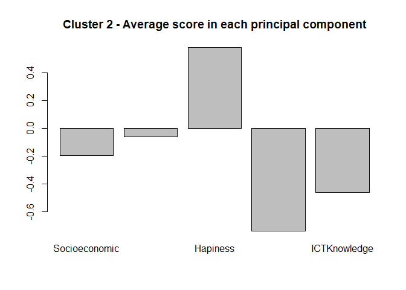

```r
barplot(colMeans(subset(IrlandaNoImput,cluster==2)[,43:47]),main= "Cluster 2 - Average score in each principal component")
```

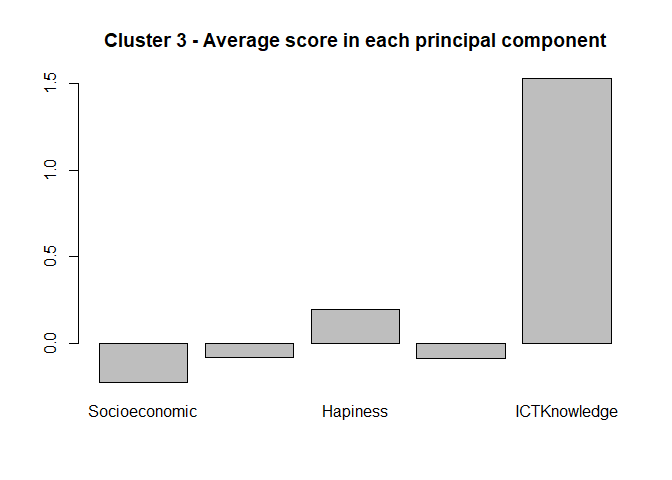

```r
barplot(colMeans(subset(IrlandaNoImput,cluster==3)[,43:47]),main= "Cluster 3 - Average score in each principal component")
```

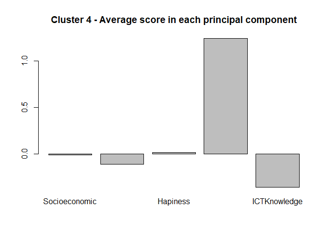

```r
barplot(colMeans(subset(IrlandaNoImput,cluster==4)[,43:47]),main= "Cluster 4 - Average score in each principal component")
```

```r
# barplot(colMeans(subset(IrlandaNoImput,cluster==5)[,44:48]),main= "Cluster 4 - Average score in each principal component")
```

```r
std_data <- scale(IrlandaNoImput[,43:47])
pam.k4 <- pam(std_data, 4)
```

```r
table(groups.k5,pam.k4$clustering)
```

```
##
## groups.k5   1   2   3   4
##         1 408  11   3  14
##         2 143 190 156   2
##         3   2 154  22 170
##         4  46 128 241 314
```

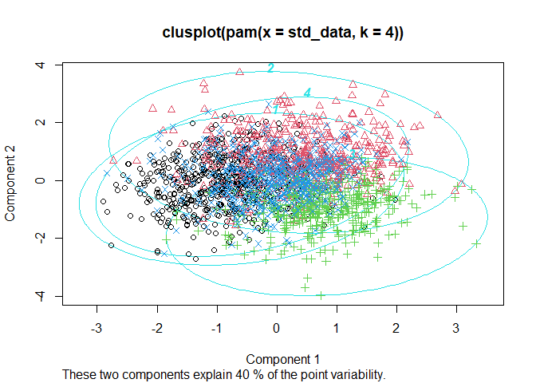

```r
clusplot(pam.k4, labels = 4, col.p = pam.k4$clustering)
```

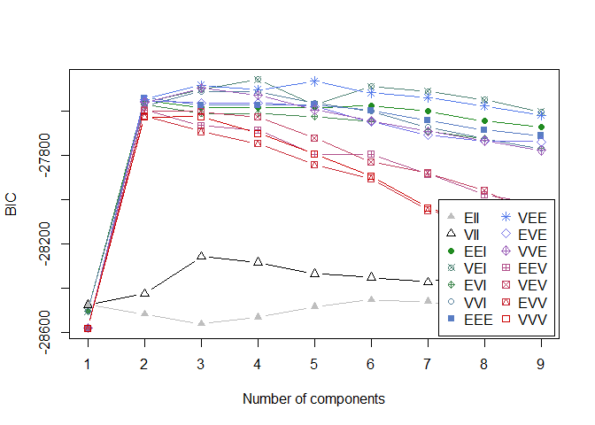

```r
data <- IrlandaNoImput[,43:47]

BIC <- mclustBIC(data)
plot(BIC)
```

```r
### GMM
set.seed(1233)

# Apply GMM with 5 components
results.G6 <- Mclust(data, G = 4)
summary(results.G6, parameters = TRUE)
```

```
## ----------------------------------------------------
## Gaussian finite mixture model fitted by EM algorithm
## ----------------------------------------------------
##
## Mclust VVI (diagonal, varying volume and shape) model with 4 components:
##
##  log-likelihood    n df       BIC       ICL
##       -13587.82 2004 43 -27502.57 -28696.11
##
## Clustering table:
##   1   2   3   4
## 534 539 219 712
##
## Mixing probabilities:
##         1         2         3         4
## 0.2307728 0.3146251 0.1506660 0.3039362
##
## Means:
##                          [,1]        [,2]        [,3]        [,4]
## Socioeconomic   -1.331855e-02  0.05976688 -0.03080468 -0.03648590
## SchoolSupport   -1.122760e-01  0.03100706 -0.02358138  0.06484112
## Hapiness         4.448395e-05 -0.10666378 -0.03924014  0.12983313
## CareerAwareness  1.195776e+00 -0.69192094  1.08136569 -0.72772466
## ICTKnowledge    -4.415531e-01  0.29490574  0.61530788 -0.27503232
##
## Variances:
## [,,1]
##                 Socioeconomic SchoolSupport  Hapiness CareerAwareness
## Socioeconomic       0.8065804     0.0000000 0.0000000       0.0000000
## SchoolSupport       0.0000000     0.8447749 0.0000000       0.0000000
## Hapiness            0.0000000     0.0000000 0.6668178       0.0000000
## CareerAwareness     0.0000000     0.0000000 0.0000000       0.1307415
## ICTKnowledge        0.0000000     0.0000000 0.0000000       0.0000000
##                 ICTKnowledge
## Socioeconomic      0.0000000
## SchoolSupport      0.0000000
## Hapiness           0.0000000
## CareerAwareness    0.0000000
## ICTKnowledge       0.3880095
## [,,2]
```

[output cut: 23 more lines]

```
## CareerAwareness     0.000000
## ICTKnowledge        1.415516
## [,,4]
##                 Socioeconomic SchoolSupport  Hapiness CareerAwareness
## Socioeconomic       0.6914335     0.0000000 0.0000000       0.0000000
## SchoolSupport       0.0000000     0.6138611 0.0000000       0.0000000
## Hapiness            0.0000000     0.0000000 0.6954058       0.0000000
## CareerAwareness     0.0000000     0.0000000 0.0000000       0.1547272
## ICTKnowledge        0.0000000     0.0000000 0.0000000       0.0000000
##                 ICTKnowledge
## Socioeconomic      0.0000000
## SchoolSupport      0.0000000
## Hapiness           0.0000000
## CareerAwareness    0.0000000
## ICTKnowledge       0.4224031
```

```r
# Some results
results.G6$modelName          # Optimal selected model
```

```
## [1] "VVI"
```

```r
results.G6$G                  # Optimal number of cluster
```

```
## [1] 4
```

```r
head(results.G6$z, 5)         # Probability to belong to a given cluster
```

```
##              [,1]         [,2]        [,3]         [,4]
## [1,] 7.917362e-01 5.091247e-08 0.208263730 1.064952e-08
## [2,] 6.541266e-01 1.322713e-02 0.325752843 6.893468e-03
## [3,] 1.044994e-08 5.990954e-01 0.001286123 3.996185e-01
## [4,] 8.750592e-01 9.172913e-07 0.124938859 9.781248e-07
## [5,] 9.022264e-01 1.399308e-05 0.097745202 1.437929e-05
```

```r
head(results.G6$classification, 5) # Cluster assignment of each observation
```

```
## [1] 1 1 2 1 1
```

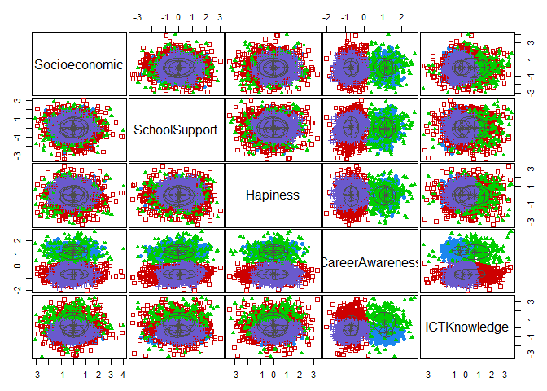

```r
# select VVI -> Variable Volume, Variable shape, Coordinate axes
plot(results.G6, what = "classification")
```

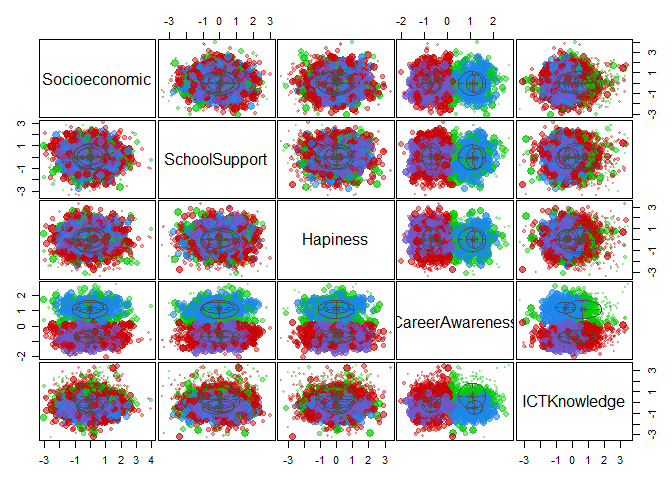

```r
plot(results.G6, what = "uncertainty")
```